# Course Project

## Activity Monitoring Data analysis

This code, after loading the libraries, loads the data and parse the *date* variable

```r
library(tidyverse)
library(lubridate)
t<- read.csv(unzip("activity.zip"))
t$date <-  ymd(t$date)
```

aggregate() function calculates total steps for each day:

```r
daily_steps <- aggregate(steps~date,t, sum)
```

This code plots the histogram of the distribution of daily steps and calculate summary statistics

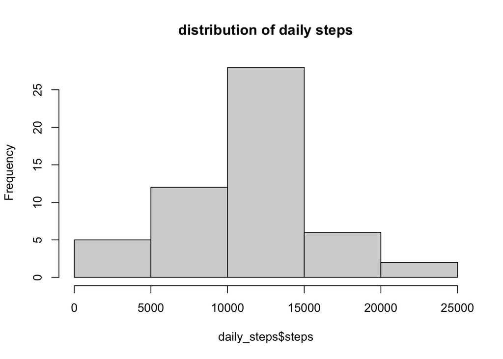

```r
hist(daily_steps$steps, main="distribution of daily steps")
```

```r
summary(daily_steps$steps)
```

```
##    Min. 1st Qu.  Median    Mean 3rd Qu.    Max.
##      41    8841   10765   10766   13294   21194
```

Here we evaluate the average number of daily steps across the intervals of time

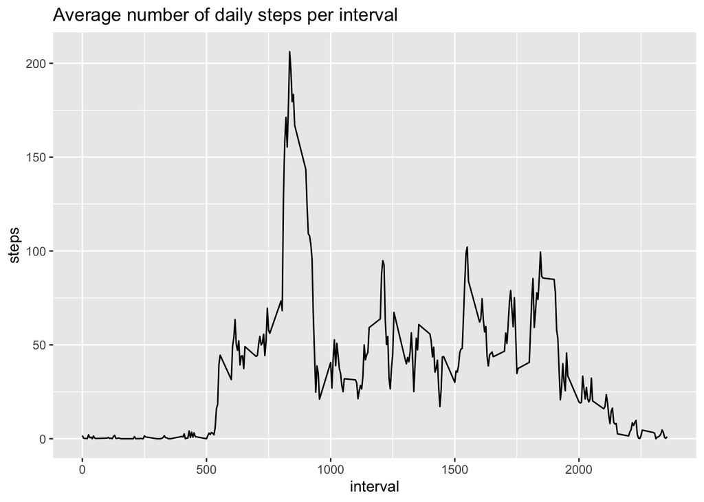

```r
avg_daily_5m_int <- aggregate(steps~interval, t, mean)

ggplot(data=avg_daily_5m_int, mapping=aes(x=interval, y=steps))+
  geom_line()+
  labs(title="Average number of daily steps per interval")
```

We look for the 5-minute interval that contains the maximum number of steps on average across all the days in the dataset:

```r
avg_daily_5m_int[which.max(avg_daily_5m_int$steps),]$interval
```

```
## [1] 835
```

This calculate and report the total number of missing values in the dataset

```r
na_list<- is.na(t$steps)
sum(na_list)
```

```
## [1] 2304
```

Dealing with missing values. They are imputed with the mean for that particular 5 minutes interval A new dataset that is equal to the original dataset but with the missing data filled in is created.

```r
match<- match(t$interval, avg_daily_5m_int$interval)

avg<- avg_daily_5m_int[match,][,2]

t<- cbind(t,avg)

imputed_t<- mutate(t, Steps=ifelse(na_list, t$avg, t$steps))
```

This makes a histogram of the total number of steps taken each day and calculate summary statitics

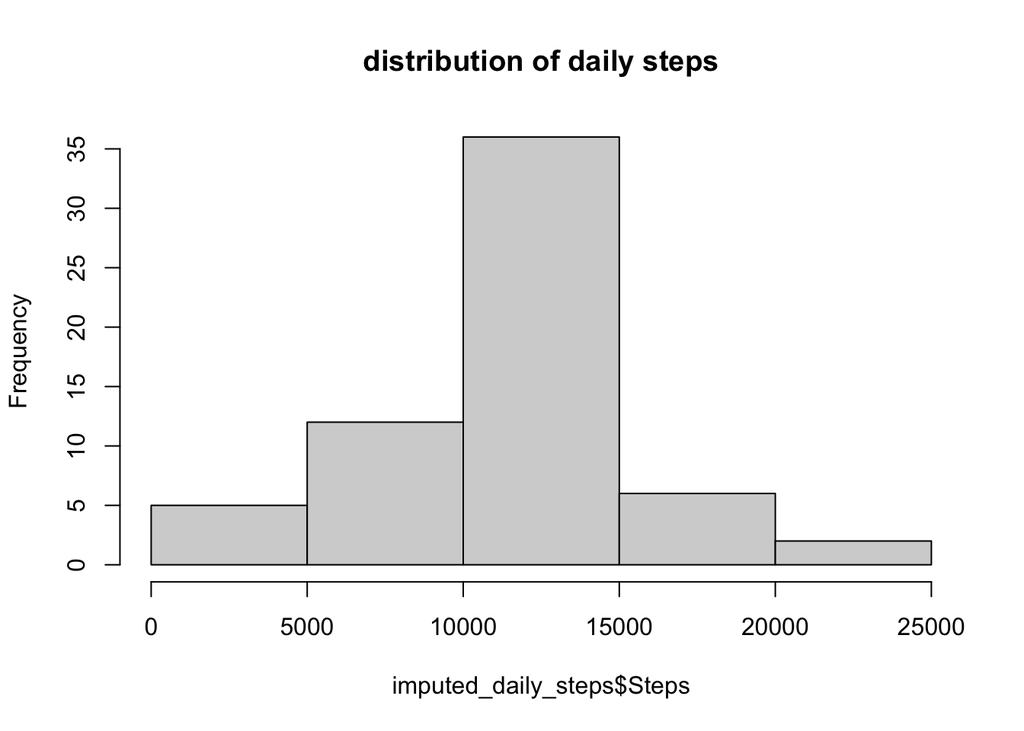

```r
imputed_daily_steps <- aggregate(Steps~date,imputed_t, sum)
hist(imputed_daily_steps$Steps, main="distribution of daily steps")
```

```r
summary(imputed_daily_steps$Steps)
```

```
##    Min. 1st Qu.  Median    Mean 3rd Qu.    Max.
##      41    9819   10766   10766   12811   21194
```

They are quite similar to the results of the original dataset

This creates a new factor variable in the dataset with two levels – “weekday” and “weekend” indicating whether a given date is a weekday or weekend day.

```r
imputed_t<- mutate(imputed_t, week_day=ifelse(wday(imputed_t$date)==1 |wday(imputed_t$date)==7, "Weekend", "Weekday"))

avg_daily_5m_int_week <- aggregate(Steps~interval+week_day, imputed_t, mean)
```

A time series plot of the 5-minute interval (x-axis) and the average number of steps taken, averaged across all weekday days or weekend days (y-axis).

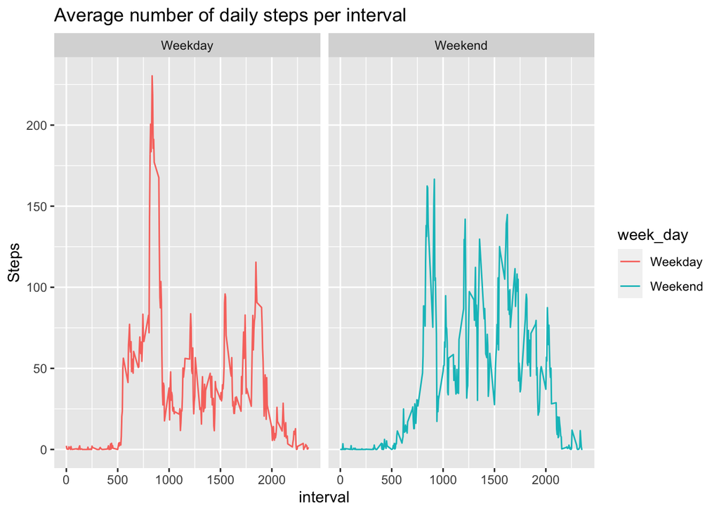

```r
ggplot(data=avg_daily_5m_int_week, mapping=aes(x=interval, y=Steps, color=week_day))+
  geom_line()+
  labs(title="Average number of daily steps per interval") +
  facet_wrap(~week_day)
```